# MB5370 Module 4 (Data Science in R) WORKSHOPS 1&2

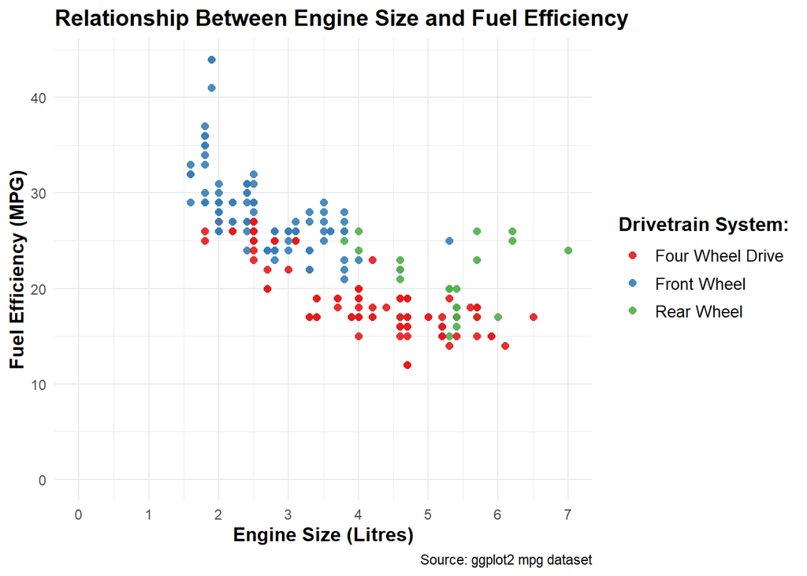

```r
## Points separated by each vehicle Drivetrain system

library(ggplot2)

ggplot(data = mpg) +
  geom_point(mapping = aes(x = displ, y = hwy, color = drv), alpha = 0.9, size = 2, shape = 16) +
  scale_x_continuous(name = "Engine Size (Litres)", breaks = seq(0, max(mpg$displ), by = 1), limits = c(0, max(mpg$displ))) +
  scale_y_continuous(name = "Fuel Efficiency (MPG)", breaks = seq(0, max(mpg$hwy), by = 10), limits = c(0, max(mpg$hwy))) +
  scale_color_manual(
    name = "Drivetrain System:",  # Legend title
    labels = c("4" = "Four Wheel Drive", "f" = "Front Wheel", "r" = "Rear Wheel"),  # Custom legend labels
    values = c("4" = "#E41A1C", "f" = "#377EB8", "r" = "#4DAF4A")  # Standard ggplot red, blue, green
  ) +
  labs(title = "Relationship Between Engine Size and Fuel Efficiency",
       caption = "Source: ggplot2 mpg dataset") +
  theme_minimal() +
  theme(legend.title = element_text(size = 12, face = "bold"),
        legend.text = element_text(size = 10),
        plot.title = element_text(size = 14, face = "bold"),
        axis.title = element_text(size = 12, face = "bold"))
```

**Add lines to the ggplot (with confidence intervals):**

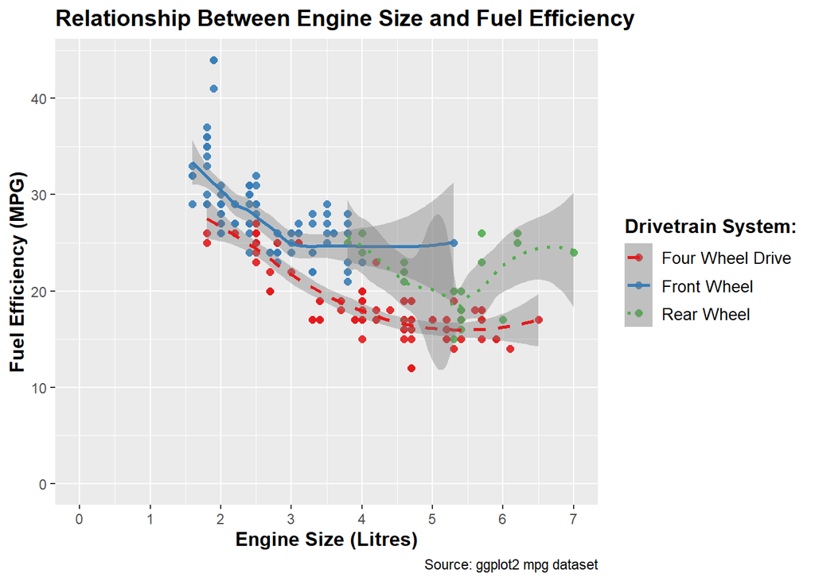

```r
library(ggplot2)

ggplot(data = mpg) +
  geom_point(mapping = aes(x = displ, y = hwy, color = drv), alpha = 0.9, size = 2, shape = 16) +
  geom_smooth(mapping = aes(x = displ, y = hwy, linetype = drv, color = drv), method = "loess", se = TRUE, linewidth = 1, fill = "grey50") +
  scale_x_continuous(name = "Engine Size (Litres)", breaks = seq(0, max(mpg$displ), by = 1), limits = c(0, max(mpg$displ))) +
  scale_y_continuous(name = "Fuel Efficiency (MPG)", breaks = seq(0, max(mpg$hwy), by = 10), limits = c(0, max(mpg$hwy))) +
  scale_color_manual(
    name = "Drivetrain System:",
    labels = c("4" = "Four Wheel Drive", "f" = "Front Wheel", "r" = "Rear Wheel"),
    values = c("4" = "#E41A1C", "f" = "#377EB8", "r" = "#4DAF4A")
  ) +
  scale_linetype_manual(
    name = "Drivetrain System:",
    labels = c("4" = "Four Wheel Drive", "f" = "Front Wheel", "r" = "Rear Wheel"),
    values = c("4" = "dashed", "f" = "solid", "r" = "dotted")
  ) +
  labs(title = "Relationship Between Engine Size and Fuel Efficiency",
       caption = "Source: ggplot2 mpg dataset") +
  theme_gray() +  # Changes the background to grey
  theme(legend.title = element_text(size = 12, face = "bold"),
        legend.text = element_text(size = 10),
        plot.title = element_text(size = 14, face = "bold"),
        axis.title = element_text(size = 12, face = "bold"))
```

## 1.3: Plot statistical details:

Colored bars within each cut quality represent the count of diamonds for each cut, grouped by clarity (fill = clarity).

Grey bars (demo dataset) → Represent a reference dataset (manually created in the demo tibble). These bars show the overall number of diamonds in each cut category (ignoring clarity), which helps compare the total number of diamonds per cut (grey) against the breakdown by clarity (colored).

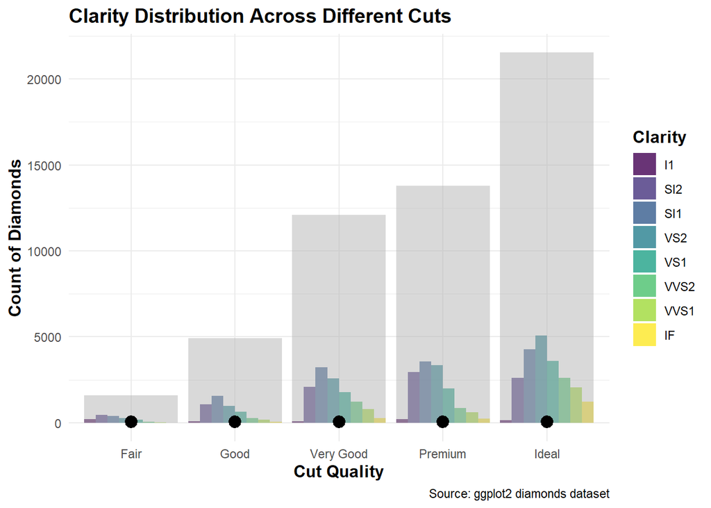

```r
library(ggplot2)
library(tibble)  # Needed for tibble()

# Creating a demo dataset (as in the example)
demo <- tribble(
  ~cut,         ~freq,
  "Fair",       1610,
  "Good",       4906,
  "Very Good",  12082,
  "Premium",    13791,
  "Ideal",      21551
)

# Main plot incorporating transformations, stats, and aesthetics
ggplot(data = diamonds) +
  geom_bar(mapping = aes(x = cut, fill = clarity), position = "dodge", alpha = 0.8) +  # Dodge bars by clarity
  geom_bar(data = demo, mapping = aes(x = cut, y = freq), stat = "identity", fill = "grey70", alpha = 0.5) +  # Add reference bars from demo dataset
  stat_summary(
    mapping = aes(x = cut, y = depth),
    fun.min = min,
    fun.max = max,
    fun = median,
    geom = "pointrange",
    color = "black",
    size = 0.8
  ) +  # Add statistical summary
  labs(
    title = "Clarity Distribution Across Different Cuts",  # Changed title
    x = "Cut Quality",
    y = "Count of Diamonds",
    fill = "Clarity",
    caption = "Source: ggplot2 diamonds dataset"
  ) +
  theme_minimal() +
  theme(legend.position = "right",
        legend.title = element_text(size = 12, face = "bold"),
        plot.title = element_text(size = 14, face = "bold"),
        axis.title = element_text(size = 12, face = "bold"))
```

# Part 2: Assignment

## 2.1: Choose data from a scientific paper:

**Paper: Half a century of global decline in oceanic sharks and rays (Pacoureau et al. 2021)**

Basing my data analysis off Figure 1 from the paper (Figure 1 - The global percentage of decline was calculated from the posteriors of the LPI around the final assessment year relative to the posteriors for 1970. The black line denotes the mean, the white lines the 95% credible intervals and the grey lines each iteration.)

## 2.2: Find two issues with the plot and create potential solutions:

**What to change:**

**1) Improve clarity of individual iterations (grey lines).**

The grey lines representing each iteration are too dense, making it hard to distinguish individual trajectories.

**Potential solution:** Reduce the number of iterations shown or adjust the transparency (alpha) of the grey lines to improve visibility without overwhelming the main trend.

**2) Enhance readability of the “Global Percentage of Decline” plot.**

The small inset plot (global percentage decline distribution) is somewhat cramped and difficult to interpret.

**Potential solution:** Increase the size of the inset plot for better readability. Change the graph to a boxplot, showing the median, interquartile range (IQR), and outliers.

## 2.3: Implement the potential solutions and reconstruct a better version of the plot:

[figure not shown]

```r
# Load necessary libraries
library(ggplot2)
library(dplyr)
library(readr)
library(gridExtra)
library(grid)

# Load dataset
df <- read_csv("../data/Pacoureau_Figure_1.csv")

# Function to extract mean, lower, and upper values from formatted LPI data
extract_lpi_values <- function(value) {
  if (grepl("\\d+ \\(\\d+\\.\\d+;\\d+\\.\\d+\\)", value)) {
    parts <- unlist(strsplit(value, " "))
    bounds <- unlist(strsplit(gsub("[()]", "", parts[2]), ";"))
    return(c(as.numeric(parts[1]), as.numeric(bounds[1]), as.numeric(bounds[2])))
  }
  return(c(NA, NA, NA))
}

# Process dataset
df_cleaned <- df %>%
  pivot_longer(-Year, names_to = "Species", values_to = "LPI") %>%
  rowwise() %>%
  mutate(LPI_Extracted = list(extract_lpi_values(LPI))) %>%
  unnest_wider(LPI_Extracted, names_sep = "_") %>%
  rename(LPI_Mean = LPI_Extracted_1, LPI_Lower = LPI_Extracted_2, LPI_Upper = LPI_Extracted_3) %>%
  select(Year, LPI_Mean, LPI_Lower, LPI_Upper) %>%
  group_by(Year) %>%
  summarise(LPI_Mean = mean(LPI_Mean, na.rm = TRUE),
            LPI_Lower = mean(LPI_Lower, na.rm = TRUE),
            LPI_Upper = mean(LPI_Upper, na.rm = TRUE))

# Create main LPI plot
main_plot <- ggplot(df_cleaned, aes(x = Year, y = LPI_Mean)) +
  geom_ribbon(aes(ymin = LPI_Lower, ymax = LPI_Upper), fill = "grey", alpha = 0.5) +
  geom_line(color = "black", size = 1.2) +
  labs(title = expression(bold("A") ~ "   Living Planet Index Decline (1970-2020)"),
       x = "Year",
       y = "Living Planet Index") +
  theme_minimal()

# Simulated decline data
inset_data <- data.frame(Decline = runif(1000, 50, 90))  # Replace with real posterior samples

# Create Boxplot for Global Percentage Decline
inset_plot <- ggplot(inset_data, aes(x = "", y = Decline)) +
  geom_boxplot(fill = "grey", alpha = 0.7) +   # Boxplot with grey fill
  geom_hline(yintercept = mean(inset_data$Decline), linetype = "dashed", color = "black") +  # Mean decline as a dashed line
  labs(title = expression(bold("B") ~ "   Global Percentage of Decline"),
       x = NULL,
       y = "Estimated Decline (%)") +
  theme_minimal()

# Arrange main plot with inset boxplot side by side
grid.arrange(main_plot, inset_plot, ncol = 2, widths = c(3, 1))
```

**Write a detailed caption for the new plot:**

# WORKSHOP 2: Using ggplot2 for communication

# Part 3: Saving and exporting ggplots

```r
# Load necessary library for saving combined plots
library(ggplot2)
library(gridExtra)
library(grid)

# Create a file name for the saved plot (change format if needed)
### output_file <- "Figure_1_redone_from_R.png"

# Save the LPI + Decline plot as a PDF (vertically so not to crop the figure)
### ggsave("Figure_1_redone_from_R.pdf",
    ###   plot = grid.arrange(main_plot, inset_plot, nrow = 2, heights = c(3, 1)),
    ###   width = 7, height = 10, device = "pdf")

# Saved in folder: "MB5370 Module 4 (Data Science in R)"
```